BIG DATA PROCESSING ON NEW YORK ACCIDENT DATA

A detailed data analysis on New York accident data set is done below. Importing the data from the local directory.

```r
main_data=read.csv(file.choose())
head(main_data)
```

```
##   CRASH.DATE CRASH.TIME  BOROUGH ZIP.CODE LATITUDE LONGITUDE
## 1 04/14/2021       5:32                NA       NA        NA
## 2 04/13/2021      21:35 BROOKLYN    11217 40.68358 -73.97617
## 3 04/15/2021      16:15                NA       NA        NA
## 4 04/13/2021      16:00 BROOKLYN    11222       NA        NA
## 5 04/12/2021       8:25                NA  0.00000   0.00000
## 6 04/13/2021      17:11                NA       NA        NA
##                LOCATION                   ON.STREET.NAME CROSS.STREET.NAME
## 1                                BRONX WHITESTONE BRIDGE
## 2 (40.68358, -73.97617)
## 3                               HUTCHINSON RIVER PARKWAY
## 4                                      VANDERVORT AVENUE    ANTHONY STREET
## 5            (0.0, 0.0) EDSON AVENUE
## 6                                 VERRAZANO BRIDGE UPPER
##                            OFF.STREET.NAME NUMBER.OF.PERSONS.INJURED
```

[output cut: 62 more lines]

TREATING THE MISSING VALUES The data contains a large amount of missing values. All the missing values in the categorical variables are changed to the most frequent occurring factor in the respective column and all the numeric variables are changed to it respective means.

```r
#missing value imputation

data_free=main_data

#replacing all missing value as NA's
data_free <- replace(data_free, data_free == "", NA)
#replacing all NA's
Mode <- function (x, na.rm) {
  xtab <- table(x)
  xmode <- names(which(xtab == max(xtab)))
  if (length(xmode) > 1) xmode <- ">1 mode"
  return(xmode)
}
for (var in 1:ncol(data_free))
  {
  if (class(data_free[,var])%in% c("numeric","integer"))
    {
    data_free[is.na(data_free[,var]),var] <- mean(data_free[,var], na.rm = TRUE)
    }
  else if (class(data_free[,var]) %in% c("character", "factor"))
    {
    data_free[is.na(data_free[,var]),var] <- tail(names(sort(table(data_free[,var]))), 1)
    }
  }
str(data_free)
```

```
## 'data.frame':    1852417 obs. of  29 variables:
##  $ CRASH.DATE                   : chr  "04/14/2021" "04/13/2021" "04/15/2021" "04/13/2021" ...
##  $ CRASH.TIME                   : chr  "5:32" "21:35" "16:15" "16:00" ...
##  $ BOROUGH                      : chr  "BROOKLYN" "BROOKLYN" "BROOKLYN" "BROOKLYN" ...
##  $ ZIP.CODE                     : num  10836 11217 10836 11222 10836 ...
##  $ LATITUDE                     : num  40.7 40.7 40.7 40.7 0 ...
##  $ LONGITUDE                    : num  -73.8 -74 -73.8 -73.8 0 ...
##  $ LOCATION                     : chr  "(0.0, 0.0)" "(40.68358, -73.97617)" "(0.0, 0.0)" "(0.0, 0.0)" ...
##  $ ON.STREET.NAME               : chr  "BRONX WHITESTONE BRIDGE" "BROADWAY                        " "HUTCHINSON RIVER PARKWAY" "VANDERVORT AVENUE" ...
##  $ CROSS.STREET.NAME            : chr  "3 AVENUE                        " "3 AVENUE                        " "3 AVENUE                        " "ANTHONY STREET" ...
##  $ OFF.STREET.NAME              : chr  "772       EDGEWATER ROAD                " "620       ATLANTIC AVENUE               " "772       EDGEWATER ROAD                " "772       EDGEWATER ROAD                " ...
##  $ NUMBER.OF.PERSONS.INJURED    : num  0 1 0 0 0 0 0 0 1 0 ...
##  $ NUMBER.OF.PERSONS.KILLED     : num  0 0 0 0 0 0 0 0 0 0 ...
##  $ NUMBER.OF.PEDESTRIANS.INJURED: int  0 1 0 0 0 0 0 0 0 0 ...
##  $ NUMBER.OF.PEDESTRIANS.KILLED : int  0 0 0 0 0 0 0 0 0 0 ...
##  $ NUMBER.OF.CYCLIST.INJURED    : int  0 0 0 0 0 0 0 0 0 0 ...
##  $ NUMBER.OF.CYCLIST.KILLED     : int  0 0 0 0 0 0 0 0 0 0 ...
##  $ NUMBER.OF.MOTORIST.INJURED   : int  0 0 0 0 0 0 0 0 1 0 ...
##  $ NUMBER.OF.MOTORIST.KILLED    : int  0 0 0 0 0 0 0 0 0 0 ...
##  $ CONTRIBUTING.FACTOR.VEHICLE.1: chr  "Following Too Closely" "Unspecified" "Pavement Slippery" "Following Too Closely" ...
##  $ CONTRIBUTING.FACTOR.VEHICLE.2: chr  "Unspecified" "Unspecified" "Unspecified" "Unspecified" ...
##  $ CONTRIBUTING.FACTOR.VEHICLE.3: chr  "Unspecified" "Unspecified" "Unspecified" "Unspecified" ...
##  $ CONTRIBUTING.FACTOR.VEHICLE.4: chr  "Unspecified" "Unspecified" "Unspecified" "Unspecified" ...
##  $ CONTRIBUTING.FACTOR.VEHICLE.5: chr  "Unspecified" "Unspecified" "Unspecified" "Unspecified" ...
##  $ COLLISION_ID                 : int  4407480 4407147 4407665 4407811 4406885 4407883 4408019 4408060 4406314 4408149 ...
##  $ VEHICLE.TYPE.CODE.1          : chr  "Sedan" "Sedan" "Station Wagon/Sport Utility Vehicle" "Sedan" ...
##  $ VEHICLE.TYPE.CODE.2          : chr  "Sedan" "Sedan" "Sedan" "Sedan" ...
##  $ VEHICLE.TYPE.CODE.3          : chr  "Sedan" "Sedan" "Sedan" "Sedan" ...
##  $ VEHICLE.TYPE.CODE.4          : chr  "Sedan" "Sedan" "Sedan" "Sedan" ...
##  $ VEHICLE.TYPE.CODE.5          : chr  "Sedan" "Sedan" "Sedan" "Sedan" ...
```

LINEAR REGRESSION Data pre-processing and splitting the data set into train and test is done before building the model.

```r
data=data_free
data=data[c('BOROUGH','ZIP.CODE','ON.STREET.NAME','NUMBER.OF.PERSONS.INJURED',
            'NUMBER.OF.PERSONS.KILLED','CONTRIBUTING.FACTOR.VEHICLE.1','CONTRIBUTING.FACTOR.VEHICLE.2',
            'VEHICLE.TYPE.CODE.1','VEHICLE.TYPE.CODE.2')]
data[sapply(data, is.character)] <- lapply(data[sapply(data, is.character)],
                                       as.factor)
#---Regression---#
rand_data <- data[sample(nrow(data), size=3000), ]
rand_data <- na.omit(rand_data)
set.seed(123)
dat.d <- sample(1:nrow(rand_data),size=nrow(rand_data)*0.7,replace = FALSE) #random selection of 70% data.
head(dat.d)
```

```
## [1] 2463 2511 2227  526  195 2986
```

```r
train.data <- rand_data[dat.d,] # 70% training data
test.data <- rand_data[-dat.d,] # remaining 30% test data
str(test.data)
```

```
## 'data.frame':    900 obs. of  9 variables:
##  $ BOROUGH                      : Factor w/ 5 levels "BRONX","BROOKLYN",..: 2 3 1 2 4 2 2 3 4 3 ...
##  $ ZIP.CODE                     : num  11201 10001 10466 11201 11420 ...
##  $ ON.STREET.NAME               : Factor w/ 16210 levels "\177estfarms road                  ",..: 14045 15485 4031 2743 200 4474 4048 2835 3960 2530 ...
##  $ NUMBER.OF.PERSONS.INJURED    : num  0 0 1 0 0 0 0 0 0 0 ...
##  $ NUMBER.OF.PERSONS.KILLED     : num  0 0 0 0 0 0 0 0 0 0 ...
##  $ CONTRIBUTING.FACTOR.VEHICLE.1: Factor w/ 61 levels "1","80","Accelerator Defective",..: 54 22 12 7 12 55 37 19 57 12 ...
##  $ CONTRIBUTING.FACTOR.VEHICLE.2: Factor w/ 61 levels "1","80","Accelerator Defective",..: 57 57 53 57 57 57 57 57 57 57 ...
##  $ VEHICLE.TYPE.CODE.1          : Factor w/ 1320 levels "\177omm","''lime mope",..: 1024 1041 977 977 1024 977 151 638 1041 1041 ...
##  $ VEHICLE.TYPE.CODE.2          : Factor w/ 1464 levels "(ceme",".","0",..: 1187 1186 1081 1149 908 1081 1081 1134 1081 1186 ...
```

Linear Model is built here

```r
#install.packages("ggplot2")
#install.packages("dplyr")
#install.packages("broom")
#install.packages("ggpubr")
library(ggplot2)
library(dplyr)
library(broom)
library(ggpubr)
str(data)
```

```
## 'data.frame':    1852417 obs. of  9 variables:
##  $ BOROUGH                      : Factor w/ 5 levels "BRONX","BROOKLYN",..: 2 2 2 2 2 2 4 2 2 2 ...
##  $ ZIP.CODE                     : num  10836 11217 10836 11222 10836 ...
##  $ ON.STREET.NAME               : Factor w/ 16210 levels "\177estfarms road                  ",..: 4021 3960 8762 14454 6767 14568 1265 13143 7802 4010 ...
##  $ NUMBER.OF.PERSONS.INJURED    : num  0 1 0 0 0 0 0 0 1 0 ...
##  $ NUMBER.OF.PERSONS.KILLED     : num  0 0 0 0 0 0 0 0 0 0 ...
##  $ CONTRIBUTING.FACTOR.VEHICLE.1: Factor w/ 61 levels "1","80","Accelerator Defective",..: 22 57 40 22 57 22 12 57 33 12 ...
##  $ CONTRIBUTING.FACTOR.VEHICLE.2: Factor w/ 61 levels "1","80","Accelerator Defective",..: 57 57 57 57 57 57 57 57 33 57 ...
##  $ VEHICLE.TYPE.CODE.1          : Factor w/ 1320 levels "\177omm","''lime mope",..: 977 977 1041 977 1041 977 977 977 977 1041 ...
##  $ VEHICLE.TYPE.CODE.2          : Factor w/ 1464 levels "(ceme",".","0",..: 1081 1081 1081 1081 1081 141 1081 1081 1081 1081 ...
```

```r
l=lm(NUMBER.OF.PERSONS.INJURED~ .  ,data=train.data)
summary(l)
```

```
##
## Call:
## lm(formula = NUMBER.OF.PERSONS.INJURED ~ ., data = train.data)
##
## Residuals:
##     Min      1Q  Median      3Q     Max
## -2.0378 -0.1658  0.0000  0.0260  3.7835
##
## Coefficients: (12 not defined because of singularities)
##                                                                                      Estimate
## (Intercept)                                                                         2.044e+00
## BOROUGHBROOKLYN                                                                     7.973e-02
## BOROUGHMANHATTAN                                                                   -1.472e-01
## BOROUGHQUEENS                                                                       1.067e-01
## BOROUGHSTATEN ISLAND                                                                4.715e-02
## ZIP.CODE                                                                           -1.565e-04
## ON.STREET.NAME1 AVENUE                                                             -2.639e-01
## ON.STREET.NAME10 AVENUE                                                            -2.043e-02
## ON.STREET.NAME101 AVENUE                                                           -9.008e-01
## ON.STREET.NAME103 STREET                                                           -3.760e-01
## ON.STREET.NAME104 STREET                                                           -5.597e-01
## ON.STREET.NAME105 AVENUE                                                           -5.213e-01
## ON.STREET.NAME107 AVENUE                                                            4.527e-01
## ON.STREET.NAME107 STREET                                                            4.760e-01
## ON.STREET.NAME108 STREET                                                           -3.974e-01
## ON.STREET.NAME109 DRIVE                                                            -5.035e-01
## ON.STREET.NAME109 STREET                                                           -3.908e-01
## ON.STREET.NAME11 AVENUE                                                            -9.117e-02
## ON.STREET.NAME11 STREET                                                             1.502e+00
## ON.STREET.NAME11 STREET                                                            -1.939e-01
## ON.STREET.NAME110 STREET                                                           -5.227e-01
## ON.STREET.NAME111 street                                                           -4.660e-01
## ON.STREET.NAME111 STREET                                                            1.115e+00
## ON.STREET.NAME114 STREET                                                            4.358e-02
## ON.STREET.NAME116 AVENUE                                                           -8.948e-01
## ON.STREET.NAME116 STREET                                                           -3.908e-01
## ON.STREET.NAME119 AVENUE                                                            7.420e-01
## ON.STREET.NAME12 AVENUE                                                            -3.450e-01
## ON.STREET.NAME121 STREET                                                           -4.088e-01
## ON.STREET.NAME122 PLACE                                                            -4.579e-01
```

[output cut: 5265 more lines]

```
## VEHICLE.TYPE.CODE.2Tow Truck / Wrecker
## VEHICLE.TYPE.CODE.2Tractor Truck Diesel
## VEHICLE.TYPE.CODE.2TRAIL
## VEHICLE.TYPE.CODE.2TRK
## VEHICLE.TYPE.CODE.2unk
## VEHICLE.TYPE.CODE.2UNKNOWN
## VEHICLE.TYPE.CODE.2UTIL
## VEHICLE.TYPE.CODE.2Van
## VEHICLE.TYPE.CODE.2VAN
## ---
## Signif. codes:  0 '***' 0.001 '**' 0.01 '*' 0.05 '.' 0.1 ' ' 1
##
## Residual standard error: 0.586 on 1052 degrees of freedom
## Multiple R-squared:  0.5706, Adjusted R-squared:  0.1433
## F-statistic: 1.335 on 1047 and 1052 DF,  p-value: 1.457e-06
```

```r
y_pred=predict(l, new_data=test.data)
head(y_pred)
```

```
##        344829          9677        948279         64419        849391
##  7.228700e-02  6.955547e-14 -5.373479e-14  2.437549e-02 -1.609823e-15
##       1410344
##  2.287059e-14
```

```r
intercept_only <- lm(NUMBER.OF.PERSONS.INJURED ~ 1, data=train.data)

#define model with all predictors
all <- lm(NUMBER.OF.PERSONS.INJURED ~ ., data=train.data)

#perform backward stepwise regression
both <- step(intercept_only, direction='both', scope=formula(all), trace=0)
summary(both)
```

```
##
## Call:
## lm(formula = NUMBER.OF.PERSONS.INJURED ~ CONTRIBUTING.FACTOR.VEHICLE.1 +
##     VEHICLE.TYPE.CODE.2 + NUMBER.OF.PERSONS.KILLED + BOROUGH,
##     data = train.data)
##
## Residuals:
##     Min      1Q  Median      3Q     Max
## -1.6871 -0.3117 -0.1883  0.0000  4.8877
##
## Coefficients:
##                                                                                     Estimate
## (Intercept)                                                                         0.814360
## CONTRIBUTING.FACTOR.VEHICLE.1Aggressive Driving/Road Rage                          -0.590088
## CONTRIBUTING.FACTOR.VEHICLE.1Alcohol Involvement                                   -0.585233
## CONTRIBUTING.FACTOR.VEHICLE.1Animals Action                                        -0.994376
## CONTRIBUTING.FACTOR.VEHICLE.1Backing Unsafely                                      -0.846639
## CONTRIBUTING.FACTOR.VEHICLE.1Brakes Defective                                      -0.426483
## CONTRIBUTING.FACTOR.VEHICLE.1Driver Inattention/Distraction                        -0.683340
## CONTRIBUTING.FACTOR.VEHICLE.1Driver Inexperience                                   -0.592833
## CONTRIBUTING.FACTOR.VEHICLE.1Driverless/Runaway Vehicle                            -1.067135
## CONTRIBUTING.FACTOR.VEHICLE.1Drugs (Illegal)                                       -0.433679
## CONTRIBUTING.FACTOR.VEHICLE.1Failure to Keep Right                                 -0.067135
## CONTRIBUTING.FACTOR.VEHICLE.1Failure to Yield Right-of-Way                         -0.501573
## CONTRIBUTING.FACTOR.VEHICLE.1Fatigued/Drowsy                                       -0.692175
## CONTRIBUTING.FACTOR.VEHICLE.1Fell Asleep                                           -0.625053
## CONTRIBUTING.FACTOR.VEHICLE.1Following Too Closely                                 -0.687480
## CONTRIBUTING.FACTOR.VEHICLE.1Glare                                                  0.380516
## CONTRIBUTING.FACTOR.VEHICLE.1Illnes                                                -0.272537
## CONTRIBUTING.FACTOR.VEHICLE.1Illness                                               -0.799110
## CONTRIBUTING.FACTOR.VEHICLE.1Lane Marking Improper/Inadequate                      -0.881770
## CONTRIBUTING.FACTOR.VEHICLE.1Lost Consciousness                                    -0.758912
## CONTRIBUTING.FACTOR.VEHICLE.1Obstruction/Debris                                    -0.737584
## CONTRIBUTING.FACTOR.VEHICLE.1Other Electronic Device                               -0.091415
## CONTRIBUTING.FACTOR.VEHICLE.1Other Vehicular                                       -0.778646
## CONTRIBUTING.FACTOR.VEHICLE.1Outside Car Distraction                               -0.677261
## CONTRIBUTING.FACTOR.VEHICLE.1Oversized Vehicle                                     -0.946923
## CONTRIBUTING.FACTOR.VEHICLE.1Passenger Distraction                                 -0.692205
## CONTRIBUTING.FACTOR.VEHICLE.1Passing or Lane Usage Improper                        -0.892244
## CONTRIBUTING.FACTOR.VEHICLE.1Passing Too Closely                                   -0.968466
```

[output cut: 437 more lines]

```
## VEHICLE.TYPE.CODE.2UNKNOWN
## VEHICLE.TYPE.CODE.2UTIL
## VEHICLE.TYPE.CODE.2Van
## VEHICLE.TYPE.CODE.2VAN
## NUMBER.OF.PERSONS.KILLED                                                           **
## BOROUGHBROOKLYN
## BOROUGHMANHATTAN                                                                   *
## BOROUGHQUEENS                                                                      .
## BOROUGHSTATEN ISLAND
## ---
## Signif. codes:  0 '***' 0.001 '**' 0.01 '*' 0.05 '.' 0.1 ' ' 1
##
## Residual standard error: 0.6115 on 2006 degrees of freedom
## Multiple R-squared:  0.1086, Adjusted R-squared:  0.06725
## F-statistic: 2.627 on 93 and 2006 DF,  p-value: 2.299e-14
```

———CLASSIFICATION———

DECISION TREE The data used is a subset of two of the most frequent observations in contributing factor 1. The two most frequent contributing factor are Driver Inattention/Distraction and Failure to Yield Right-of-Way. Note:- Unspecified is actually the most frequent observation here, so the most frequent observations after this character is taken.

```r
data=data_free
data=data[c('COLLISION_ID','CRASH.TIME','BOROUGH','ZIP.CODE','ON.STREET.NAME','NUMBER.OF.PERSONS.INJURED',
            'NUMBER.OF.PERSONS.KILLED','CONTRIBUTING.FACTOR.VEHICLE.1','CONTRIBUTING.FACTOR.VEHICLE.2',
            'VEHICLE.TYPE.CODE.1','VEHICLE.TYPE.CODE.2','LOCATION','NUMBER.OF.PEDESTRIANS.INJURED','NUMBER.OF.PEDESTRIANS.KILLED',
            'NUMBER.OF.CYCLIST.INJURED','NUMBER.OF.CYCLIST.KILLED','NUMBER.OF.MOTORIST.INJURED','NUMBER.OF.MOTORIST.KILLED')]
#getting the most frequent factor for an accident
tail(names(sort(table(data$CONTRIBUTING.FACTOR.VEHICLE.1))), 3)
```

```
## [1] "Failure to Yield Right-of-Way"  "Driver Inattention/Distraction"
## [3] "Unspecified"
```

```r
#subsetting the data for the most frequent factor
d1=subset(data,data$CONTRIBUTING.FACTOR.VEHICLE.1=="Driver Inattention/Distraction" | data$CONTRIBUTING.FACTOR.VEHICLE.1=="Failure to Yield Right-of-Way")
str(d1)
```

```
## 'data.frame':    467491 obs. of  18 variables:
##  $ COLLISION_ID                 : int  4408019 4408149 4277087 4405244 4405914 4407885 4407616 4408224 4407765 4407520 ...
##  $ CRASH.TIME                   : chr  "17:30" "21:15" "15:49" "22:58" ...
##  $ BOROUGH                      : chr  "QUEENS" "BROOKLYN" "BROOKLYN" "STATEN ISLAND" ...
##  $ ZIP.CODE                     : num  11106 10836 10836 10312 10836 ...
##  $ ON.STREET.NAME               : chr  "33 st" "BRONX RIVER PARKWAY RAMP" "BRUCKNER BLVD" "BARCLAY AVENUE" ...
##  $ NUMBER.OF.PERSONS.INJURED    : num  0 0 0 7 1 0 0 0 0 0 ...
##  $ NUMBER.OF.PERSONS.KILLED     : num  0 0 0 0 0 0 0 0 0 0 ...
##  $ CONTRIBUTING.FACTOR.VEHICLE.1: chr  "Driver Inattention/Distraction" "Driver Inattention/Distraction" "Driver Inattention/Distraction" "Failure to Yield Right-of-Way" ...
##  $ CONTRIBUTING.FACTOR.VEHICLE.2: chr  "Unspecified" "Unspecified" "Unspecified" "Unsafe Speed" ...
##  $ VEHICLE.TYPE.CODE.1          : chr  "Sedan" "Station Wagon/Sport Utility Vehicle" "Sedan" "Station Wagon/Sport Utility Vehicle" ...
##  $ VEHICLE.TYPE.CODE.2          : chr  "Sedan" "Sedan" "Station Wagon/Sport Utility Vehicle" "Station Wagon/Sport Utility Vehicle" ...
##  $ LOCATION                     : chr  "(0.0, 0.0)" "(0.0, 0.0)" "(0.0, 0.0)" "(40.526894, -74.16728)" ...
##  $ NUMBER.OF.PEDESTRIANS.INJURED: int  0 0 0 0 0 0 0 0 0 0 ...
##  $ NUMBER.OF.PEDESTRIANS.KILLED : int  0 0 0 0 0 0 0 0 0 0 ...
##  $ NUMBER.OF.CYCLIST.INJURED    : int  0 0 0 0 0 0 0 0 0 0 ...
##  $ NUMBER.OF.CYCLIST.KILLED     : int  0 0 0 0 0 0 0 0 0 0 ...
##  $ NUMBER.OF.MOTORIST.INJURED   : int  0 0 0 7 1 0 0 0 0 0 ...
##  $ NUMBER.OF.MOTORIST.KILLED    : int  0 0 0 0 0 0 0 0 0 0 ...
```

Splitting into train and test

```r
#splitting
rand_data <- d1[sample(nrow(d1), size=300), ]
set.seed(123)
dat.d <- sample(1:nrow(rand_data),size=nrow(rand_data)*0.7,replace = FALSE) #random selection of 70% data.
train.data <- rand_data[dat.d,] # 70% training data
test.data <- rand_data[-dat.d,] # remaining 30% test data
str(test.data)
```

```
## 'data.frame':    90 obs. of  18 variables:
##  $ COLLISION_ID                 : int  1012019 4383331 3679035 4050565 3797937 4396360 3652646 3518533 3763373 3856668 ...
##  $ CRASH.TIME                   : chr  "12:40" "14:40" "21:46" "19:15" ...
##  $ BOROUGH                      : chr  "MANHATTAN" "QUEENS" "BRONX" "QUEENS" ...
##  $ ZIP.CODE                     : num  10012 11370 10468 11434 10836 ...
##  $ ON.STREET.NAME               : chr  "KENMARE STREET                  " "82 STREET                       " "BROADWAY                        " "137 AVENUE                      " ...
##  $ NUMBER.OF.PERSONS.INJURED    : num  0 0 0 1 0 0 1 0 1 0 ...
##  $ NUMBER.OF.PERSONS.KILLED     : num  0 0 0 0 0 0 0 0 0 0 ...
##  $ CONTRIBUTING.FACTOR.VEHICLE.1: chr  "Failure to Yield Right-of-Way" "Driver Inattention/Distraction" "Failure to Yield Right-of-Way" "Driver Inattention/Distraction" ...
##  $ CONTRIBUTING.FACTOR.VEHICLE.2: chr  "Unspecified" "Unspecified" "Unspecified" "Unspecified" ...
##  $ VEHICLE.TYPE.CODE.1          : chr  "PASSENGER VEHICLE" "Sedan" "Station Wagon/Sport Utility Vehicle" "Sedan" ...
##  $ VEHICLE.TYPE.CODE.2          : chr  "PASSENGER VEHICLE" "Sedan" "Station Wagon/Sport Utility Vehicle" "Sedan" ...
##  $ LOCATION                     : chr  "(40.7203211, -73.9940403)" "(40.76635, -73.88756)" "(40.86269, -73.90268)" "(40.6728, -73.76941)" ...
##  $ NUMBER.OF.PEDESTRIANS.INJURED: int  0 0 0 1 0 0 1 0 0 0 ...
##  $ NUMBER.OF.PEDESTRIANS.KILLED : int  0 0 0 0 0 0 0 0 0 0 ...
##  $ NUMBER.OF.CYCLIST.INJURED    : int  0 0 0 0 0 0 0 0 0 0 ...
##  $ NUMBER.OF.CYCLIST.KILLED     : int  0 0 0 0 0 0 0 0 0 0 ...
##  $ NUMBER.OF.MOTORIST.INJURED   : int  0 0 0 0 0 0 0 0 1 0 ...
##  $ NUMBER.OF.MOTORIST.KILLED    : int  0 0 0 0 0 0 0 0 0 0 ...
```

```r
#decision tree
library(rpart)
```

Decision tree model Two models are build here. Model 1 uses a subset of the data set as variables and model 2 uses the full data set. The two models are compared later.

Model 1

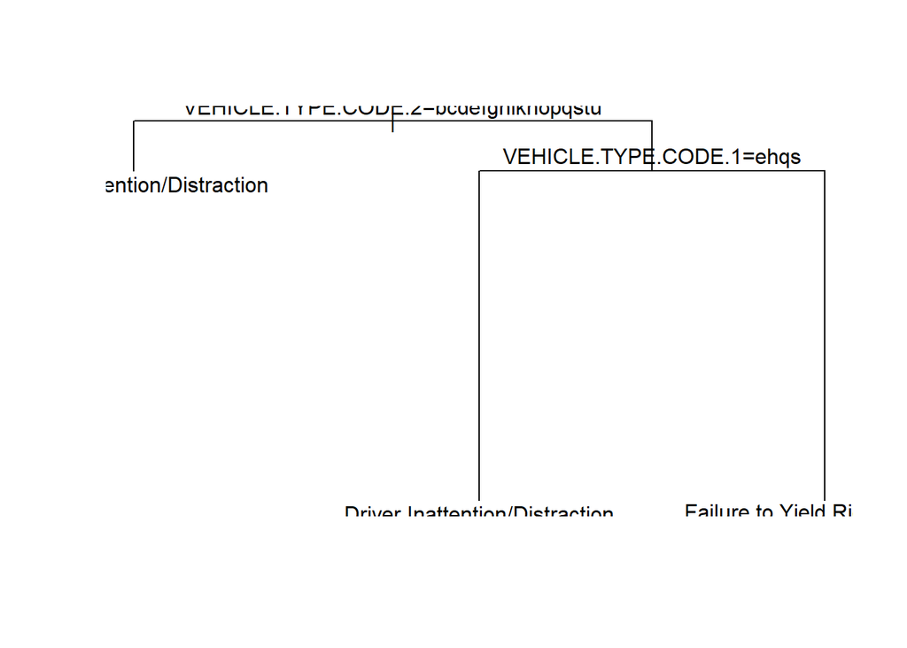

```r
library(rpart)
model1=rpart(CONTRIBUTING.FACTOR.VEHICLE.1~NUMBER.OF.PERSONS.INJURED+NUMBER.OF.PERSONS.KILLED+
               VEHICLE.TYPE.CODE.1+VEHICLE.TYPE.CODE.2+NUMBER.OF.PEDESTRIANS.INJURED+NUMBER.OF.PEDESTRIANS.KILLED,
             data=train.data,cp=0)
plot(model1)
text(model1)
```

Model 2

```r
model2=rpart(CONTRIBUTING.FACTOR.VEHICLE.1~.
             ,data=train.data,cp=0)
```

Predicting the decision tree models

```r
#testing the  model performance
pred=predict(model1,train.data,type='class')
tbl1<-table(pred, train.data $CONTRIBUTING.FACTOR.VEHICLE.1)
print(tbl1)
```

```
##
## pred                             Driver Inattention/Distraction
##   Driver Inattention/Distraction                            157
##   Failure to Yield Right-of-Way                               7
##
## pred                             Failure to Yield Right-of-Way
##   Driver Inattention/Distraction                            37
##   Failure to Yield Right-of-Way                              9
```

```r
pred=predict(model2,train.data,type='class')
tbl2<-table(pred, train.data $CONTRIBUTING.FACTOR.VEHICLE.1)
print(tbl2)
```

```
##
## pred                             Driver Inattention/Distraction
##   Driver Inattention/Distraction                            164
##   Failure to Yield Right-of-Way                               0
##
## pred                             Failure to Yield Right-of-Way
##   Driver Inattention/Distraction                             3
##   Failure to Yield Right-of-Way                             43
```

Second model with full variable is likely to be a better model to prediction.

K-NN A K-NN algorithm is built to predict the most occurring time of accident.

```r
data=data_free
d1=data[c('COLLISION_ID','CRASH.TIME','BOROUGH','ZIP.CODE','ON.STREET.NAME','NUMBER.OF.PERSONS.INJURED',
            'NUMBER.OF.PERSONS.KILLED','CONTRIBUTING.FACTOR.VEHICLE.1','CONTRIBUTING.FACTOR.VEHICLE.2',
            'VEHICLE.TYPE.CODE.1','VEHICLE.TYPE.CODE.2','LOCATION','NUMBER.OF.PEDESTRIANS.INJURED','NUMBER.OF.PEDESTRIANS.KILLED',
            'NUMBER.OF.CYCLIST.INJURED','NUMBER.OF.CYCLIST.KILLED','NUMBER.OF.MOTORIST.INJURED','NUMBER.OF.MOTORIST.KILLED')]
```

The most frequent time of accident is found to be 16:00 and 17:00 (school and office return time). A model is build on factors like borough,vehicle type etc.

```r
tail(names(sort(table(d1$CRASH.TIME))), 3)
```

```
## [1] "15:00" "17:00" "16:00"
```

```r
d1=subset(data,(data$CRASH.TIME=="16:00" | data$CRASH.TIME=="17:00"))
d1=d1[c('CRASH.TIME','BOROUGH','VEHICLE.TYPE.CODE.1','VEHICLE.TYPE.CODE.2','CONTRIBUTING.FACTOR.VEHICLE.1','CONTRIBUTING.FACTOR.VEHICLE.2'
                      )]
d1$CONTRIBUTING.FACTOR.VEHICLE.1  <- as.numeric(as.factor(d1$CONTRIBUTING.FACTOR.VEHICLE.1))
d1$CONTRIBUTING.FACTOR.VEHICLE.2 <- as.numeric(as.factor(d1$CONTRIBUTING.FACTOR.VEHICLE.2))
d1$VEHICLE.TYPE.CODE.1   <- as.numeric(as.factor(d1$VEHICLE.TYPE.CODE.1 ))
d1$VEHICLE.TYPE.CODE.2  <- as.numeric(as.factor(d1$VEHICLE.TYPE.CODE.2))
d1$BOROUGH  <- as.numeric(as.factor(d1$BOROUGH))
```

Splitting of train and test for K-NN Model

```r
d1$VEHICLE.TYPE.CODE.1  <- as.numeric(as.factor(d1$VEHICLE.TYPE.CODE.1))

#splitting
rand_data <- d1[sample(nrow(d1), size=30000), ]
rand_data=rand_data[,-10]
set.seed(123)
dat.d <- sample(1:nrow(rand_data),size=nrow(rand_data)*0.7,replace = FALSE) #random selection of 70% data.
train.data <- rand_data[dat.d,] # 70% training data
test.data <- rand_data[-dat.d,] # remaining 30% test data
str(test.data)
```

```
## 'data.frame':    9000 obs. of  6 variables:
##  $ CRASH.TIME                   : chr  "16:00" "16:00" "17:00" "16:00" ...
##  $ BOROUGH                      : num  2 2 2 2 5 2 4 3 4 2 ...
##  $ VEHICLE.TYPE.CODE.1          : num  136 127 127 3 3 122 3 3 106 122 ...
##  $ VEHICLE.TYPE.CODE.2          : num  131 137 169 4 131 115 131 4 137 131 ...
##  $ CONTRIBUTING.FACTOR.VEHICLE.1: num  11 19 55 35 55 55 11 11 7 11 ...
##  $ CONTRIBUTING.FACTOR.VEHICLE.2: num  48 48 48 31 48 48 48 48 48 48 ...
```

```r
train.data[-1]=scale(train.data[-1])
test.data[-1]=scale(test.data[-1])
train.data=na.omit(train.data)
test.data=na.omit(test.data)
```

Model Building A k-NN model is built and is predicted on the test data set for cheking the performance of the model.

```r
#model building
#install.packages('caTools')
library(class)
y_pred=knn(train=train.data[,-1],
           test=test.data[,-1],
           cl=train.data[,1],
           k=5)


head(y_pred)
```

```
## [1] 17:00 17:00 17:00 17:00 17:00 17:00
## Levels: 16:00 17:00
```

```r
cm=table(test.data[,1] , y_pred)
cm
```

```
##        y_pred
##         16:00 17:00
##   16:00  2268  2255
##   17:00  2228  2249
```

The model performance suggest that almost 50% of the time the time of the crash were correctly predicted.

```r
data=data_free
data=data[c('COLLISION_ID','CRASH.TIME','BOROUGH','ZIP.CODE','ON.STREET.NAME','NUMBER.OF.PERSONS.INJURED',
'NUMBER.OF.PERSONS.KILLED','CONTRIBUTING.FACTOR.VEHICLE.1','CONTRIBUTING.FACTOR.VEHICLE.2',
'VEHICLE.TYPE.CODE.1','VEHICLE.TYPE.CODE.2','LOCATION','NUMBER.OF.PEDESTRIANS.INJURED','NUMBER.OF.PEDESTRIANS.KILLED',
'NUMBER.OF.CYCLIST.INJURED','NUMBER.OF.CYCLIST.KILLED','NUMBER.OF.MOTORIST.INJURED','NUMBER.OF.MOTORIST.KILLED')]
#getting the most frequent vehicle to cause an accident
tail(names(sort(table(data$VEHICLE.TYPE.CODE.1))), 3)
```

```
## [1] "Station Wagon/Sport Utility Vehicle" "PASSENGER VEHICLE"
## [3] "Sedan"
```

```r
#subsetting the data for the most frequent vehicle in accident
d2=subset(data,data$VEHICLE.TYPE.CODE.1=="Station Wagon/Sport Utility Vehicle" | data$VEHICLE.TYPE.CODE.1=="PASSENGER VEHICLE")
str(d2)
```

```
## 'data.frame':    792317 obs. of  18 variables:
##  $ COLLISION_ID                 : int  4407665 4406885 4408149 4406097 4395664 4405244 4408191 4407366 4407407 4408143 ...
##  $ CRASH.TIME                   : chr  "16:15" "8:25" "21:15" "11:15" ...
##  $ BOROUGH                      : chr  "BROOKLYN" "BROOKLYN" "BROOKLYN" "BROOKLYN" ...
##  $ ZIP.CODE                     : num  10836 10836 10836 10836 10461 ...
##  $ ON.STREET.NAME               : chr  "HUTCHINSON RIVER PARKWAY" "EDSON AVENUE                    " "BRONX RIVER PARKWAY RAMP" "BROOKLYN BRIDGE                 " ...
##  $ NUMBER.OF.PERSONS.INJURED    : num  0 0 0 0 0 7 0 1 0 2 ...
##  $ NUMBER.OF.PERSONS.KILLED     : num  0 0 0 0 0 0 0 0 0 0 ...
##  $ CONTRIBUTING.FACTOR.VEHICLE.1: chr  "Pavement Slippery" "Unspecified" "Driver Inattention/Distraction" "Unspecified" ...
##  $ CONTRIBUTING.FACTOR.VEHICLE.2: chr  "Unspecified" "Unspecified" "Unspecified" "Unspecified" ...
##  $ VEHICLE.TYPE.CODE.1          : chr  "Station Wagon/Sport Utility Vehicle" "Station Wagon/Sport Utility Vehicle" "Station Wagon/Sport Utility Vehicle" "Station Wagon/Sport Utility Vehicle" ...
##  $ VEHICLE.TYPE.CODE.2          : chr  "Sedan" "Sedan" "Sedan" "Station Wagon/Sport Utility Vehicle" ...
##  $ LOCATION                     : chr  "(0.0, 0.0)" "(0.0, 0.0)" "(0.0, 0.0)" "(0.0, 0.0)" ...
##  $ NUMBER.OF.PEDESTRIANS.INJURED: int  0 0 0 0 0 0 0 0 0 0 ...
##  $ NUMBER.OF.PEDESTRIANS.KILLED : int  0 0 0 0 0 0 0 0 0 0 ...
##  $ NUMBER.OF.CYCLIST.INJURED    : int  0 0 0 0 0 0 0 0 0 0 ...
##  $ NUMBER.OF.CYCLIST.KILLED     : int  0 0 0 0 0 0 0 0 0 0 ...
##  $ NUMBER.OF.MOTORIST.INJURED   : int  0 0 0 0 0 7 0 1 0 2 ...
##  $ NUMBER.OF.MOTORIST.KILLED    : int  0 0 0 0 0 0 0 0 0 0 ...
```

splitting

```r
#splitting
rand_data <- d2[sample(nrow(d2), size=300), ]
set.seed(123)
dat.d <- sample(1:nrow(rand_data),size=nrow(rand_data)*0.7,replace = FALSE) #random selection of 70% data.
train.data <- rand_data[dat.d,] # 70% training data
test.data <- rand_data[-dat.d,] # remaining 30% test data
str(test.data)
```

```
## 'data.frame':    90 obs. of  18 variables:
##  $ COLLISION_ID                 : int  3537935 314805 4183199 3248121 4233243 4343751 108234 3683050 3982341 35797 ...
##  $ CRASH.TIME                   : chr  "16:35" "12:50" "17:30" "23:00" ...
##  $ BOROUGH                      : chr  "BRONX" "QUEENS" "BROOKLYN" "MANHATTAN" ...
##  $ ZIP.CODE                     : num  10467 11366 10836 10017 10836 ...
##  $ ON.STREET.NAME               : chr  "BROADWAY                        " "188 STREET                      " "BROADWAY                        " "PARK AVENUE                     " ...
##  $ NUMBER.OF.PERSONS.INJURED    : num  0 0 0 0 0 3 0 0 0 0 ...
##  $ NUMBER.OF.PERSONS.KILLED     : num  0 0 0 0 0 0 0 0 0 0 ...
##  $ CONTRIBUTING.FACTOR.VEHICLE.1: chr  "Backing Unsafely" "Unspecified" "Driver Inattention/Distraction" "Driver Inattention/Distraction" ...
##  $ CONTRIBUTING.FACTOR.VEHICLE.2: chr  "Unspecified" "Unspecified" "Driver Inattention/Distraction" "Driver Inattention/Distraction" ...
##  $ VEHICLE.TYPE.CODE.1          : chr  "Station Wagon/Sport Utility Vehicle" "PASSENGER VEHICLE" "Station Wagon/Sport Utility Vehicle" "PASSENGER VEHICLE" ...
##  $ VEHICLE.TYPE.CODE.2          : chr  "Sedan" "PASSENGER VEHICLE" "Bus" "TAXI" ...
##  $ LOCATION                     : chr  "(40.877777, -73.87385)" "(40.7312534, -73.7821329)" "(40.72179, -73.99986)" "(40.7553005, -73.9753439)" ...
##  $ NUMBER.OF.PEDESTRIANS.INJURED: int  0 0 0 0 0 0 0 0 0 0 ...
##  $ NUMBER.OF.PEDESTRIANS.KILLED : int  0 0 0 0 0 0 0 0 0 0 ...
##  $ NUMBER.OF.CYCLIST.INJURED    : int  0 0 0 0 0 0 0 0 0 0 ...
##  $ NUMBER.OF.CYCLIST.KILLED     : int  0 0 0 0 0 0 0 0 0 0 ...
##  $ NUMBER.OF.MOTORIST.INJURED   : int  0 0 0 0 0 3 0 0 0 0 ...
##  $ NUMBER.OF.MOTORIST.KILLED    : int  0 0 0 0 0 0 0 0 0 0 ...
```

Naive bayes Model building

```r
library(e1071)
model2=naiveBayes(VEHICLE.TYPE.CODE.1~.,data=train.data)
predictions=predict(model2,train.data,type="raw")
pred=ifelse(predictions[,1]>=.5,"PASSENGER VEHICLE","Station Wagon/Sport Utility Vehicle")
prop.table(table(pred,train.data$VEHICLE.TYPE.CODE.1))
```

```
##
## pred                                  PASSENGER VEHICLE
##   PASSENGER VEHICLE                           0.5571429
##   Station Wagon/Sport Utility Vehicle         0.0000000
##
## pred                                  Station Wagon/Sport Utility Vehicle
##   PASSENGER VEHICLE                                             0.0000000
##   Station Wagon/Sport Utility Vehicle                           0.4428571
```

The naive Bayes seems like a good prediction model to predict the vehicle type in accidents. The mis-classification errors suggest that naive Bayes is a good predictor in this situation

—————CLUSTERING———— K-Means clustering Data Pre-processing and scaling is done before K -means clustering.

```r
data=data_free
d<- data[sample(nrow(data), size=1000), ]
d=d[c('NUMBER.OF.PERSONS.INJURED',
                'CONTRIBUTING.FACTOR.VEHICLE.1','CONTRIBUTING.FACTOR.VEHICLE.2',
                 'VEHICLE.TYPE.CODE.1','VEHICLE.TYPE.CODE.2','NUMBER.OF.PEDESTRIANS.INJURED')]

d$CONTRIBUTING.FACTOR.VEHICLE.1  <- as.numeric(as.factor(d$CONTRIBUTING.FACTOR.VEHICLE.1))
d$CONTRIBUTING.FACTOR.VEHICLE.2 <- as.numeric(as.factor(d$CONTRIBUTING.FACTOR.VEHICLE.2))
d$VEHICLE.TYPE.CODE.1   <- as.numeric(as.factor(d$VEHICLE.TYPE.CODE.1 ))
d$VEHICLE.TYPE.CODE.2  <- as.numeric(as.factor(d$VEHICLE.TYPE.CODE.2))




d=scale(d)
```

Scree Plot The number of clusters are decided using an elbow method

```r
library(factoextra)
```

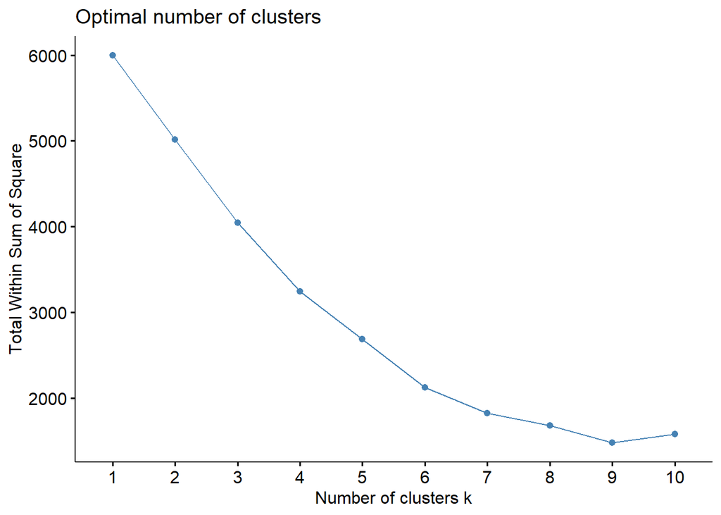

```r
library(cluster)
fviz_nbclust(d, kmeans, method = "wss")
```

K-Means model

```r
set.seed(1)

#perform k-means clustering with k = 5 clusters
km <- kmeans(d, centers = 5, nstart = 25)
```

Plotting the clusters

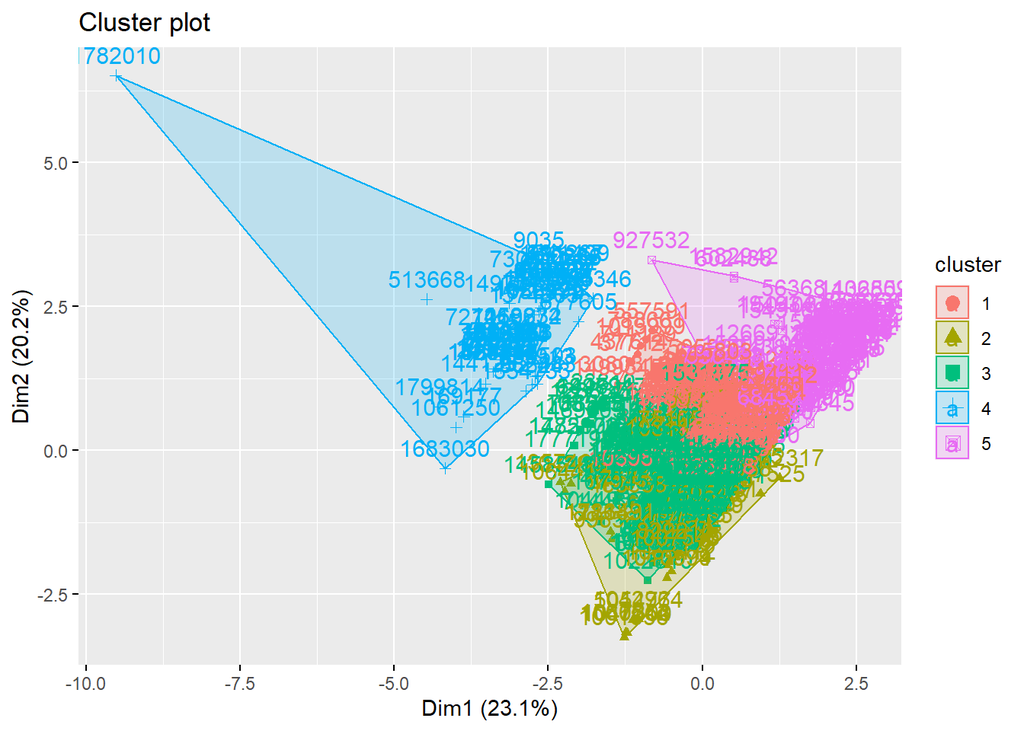

```r
#plot results of final k-means model
fviz_cluster(km, data = d)
```

The final step is to add the clusters to the original data

```r
final_data <- cbind(d, cluster = km$cluster)

#view final data
head(final_data)
```

```
##         NUMBER.OF.PERSONS.INJURED CONTRIBUTING.FACTOR.VEHICLE.1
## 1357466                 2.7741209                     1.0585671
## 547540                 -0.4441168                     0.1258456
## 382450                 -0.4441168                    -0.2328934
## 1579668                -0.4441168                     1.0585671
## 196569                 -0.4441168                    -1.2373626
## 874145                 -0.4441168                     0.9150715
##         CONTRIBUTING.FACTOR.VEHICLE.2 VEHICLE.TYPE.CODE.1 VEHICLE.TYPE.CODE.2
## 1357466                     0.3714082          -0.4586211          -2.4794551
## 547540                      0.3714082           0.6757774           0.1890168
## 382450                     -1.7171105           0.6757774           0.1890168
## 1579668                     0.3714082           0.5137205           0.4855136
## 196569                      0.3714082          -2.0791905           0.6337621
## 874145                      0.3714082           0.6757774           0.1890168
##         NUMBER.OF.PEDESTRIANS.INJURED cluster
## 1357466                    -0.2354211       2
## 547540                     -0.2354211       3
## 382450                     -0.2354211       5
## 1579668                    -0.2354211       3
## 196569                     -0.2354211       1
## 874145                     -0.2354211       3
```

———–DEEP LEARNING———— Neural Network The data is subsetted to two of the most frequent factors in crash time, vehicle type1, contributing factor1, and borough.

```r
data=data_free
data=data[c('COLLISION_ID','CRASH.TIME','BOROUGH','ZIP.CODE','ON.STREET.NAME','NUMBER.OF.PERSONS.INJURED',
            'NUMBER.OF.PERSONS.KILLED','CONTRIBUTING.FACTOR.VEHICLE.1','CONTRIBUTING.FACTOR.VEHICLE.2',
            'VEHICLE.TYPE.CODE.1','VEHICLE.TYPE.CODE.2','LOCATION','NUMBER.OF.PEDESTRIANS.INJURED','NUMBER.OF.PEDESTRIANS.KILLED',
            'NUMBER.OF.CYCLIST.INJURED','NUMBER.OF.CYCLIST.KILLED','NUMBER.OF.MOTORIST.INJURED','NUMBER.OF.MOTORIST.KILLED')]
#getting the most frequent vehicle to cause an accident
tail(names(sort(table(data$CRASH.TIME))), 3)
```

```
## [1] "15:00" "17:00" "16:00"
```

```r
tail(names(sort(table(data$BOROUGH))), 3)
```

```
## [1] "MANHATTAN" "QUEENS"    "BROOKLYN"
```

```r
tail(names(sort(table(data$CONTRIBUTING.FACTOR.VEHICLE.1))), 3)
```

```
## [1] "Failure to Yield Right-of-Way"  "Driver Inattention/Distraction"
## [3] "Unspecified"
```

```r
tail(names(sort(table(data$VEHICLE.TYPE.CODE.1))), 3)
```

```
## [1] "Station Wagon/Sport Utility Vehicle" "PASSENGER VEHICLE"
## [3] "Sedan"
```

```r
d1=subset(data,(data$VEHICLE.TYPE.CODE.1=="Station Wagon/Sport Utility Vehicle" | data$VEHICLE.TYPE.CODE.1=="PASSENGER VEHICLE" ) &
         (data$CRASH.TIME=="16:00" | data$CRASH.TIME=="17:00") &
           (data$BOROUGH=="BROOKLYN" | data$BOROUGH=="QUEENS") &            (data$CONTRIBUTING.FACTOR.VEHICLE.1=="Driver Inattention/Distraction" |  data$CONTRIBUTING.FACTOR.VEHICLE.1=="Failure to Yield Right-of-Way"))

str(d1)
```

```
## 'data.frame':    4486 obs. of  18 variables:
##  $ COLLISION_ID                 : int  4408010 4408623 4408731 4409553 4409413 4410300 4410475 4410764 4411789 4411782 ...
##  $ CRASH.TIME                   : chr  "17:00" "16:00" "17:00" "17:00" ...
##  $ BOROUGH                      : chr  "QUEENS" "BROOKLYN" "BROOKLYN" "BROOKLYN" ...
##  $ ZIP.CODE                     : num  11101 11208 10836 10836 10836 ...
##  $ ON.STREET.NAME               : chr  "HUNTER STREET" "BROADWAY                        " "MERMAID AVENUE" "LINDEN BOULEVARD" ...
##  $ NUMBER.OF.PERSONS.INJURED    : num  0 0 0 0 1 0 0 1 0 0 ...
##  $ NUMBER.OF.PERSONS.KILLED     : num  0 0 0 0 0 0 0 0 0 0 ...
##  $ CONTRIBUTING.FACTOR.VEHICLE.1: chr  "Driver Inattention/Distraction" "Driver Inattention/Distraction" "Driver Inattention/Distraction" "Driver Inattention/Distraction" ...
##  $ CONTRIBUTING.FACTOR.VEHICLE.2: chr  "Unspecified" "Driver Inexperience" "Unspecified" "Unspecified" ...
##  $ VEHICLE.TYPE.CODE.1          : chr  "Station Wagon/Sport Utility Vehicle" "Station Wagon/Sport Utility Vehicle" "Station Wagon/Sport Utility Vehicle" "Station Wagon/Sport Utility Vehicle" ...
##  $ VEHICLE.TYPE.CODE.2          : chr  "Sedan" "Station Wagon/Sport Utility Vehicle" "Sedan" "Sedan" ...
##  $ LOCATION                     : chr  "(40.74898, -73.93969)" "(40.67854, -73.88094)" "(40.575336, -73.996445)" "(40.657555, -73.894196)" ...
##  $ NUMBER.OF.PEDESTRIANS.INJURED: int  0 0 0 0 0 0 0 0 0 0 ...
##  $ NUMBER.OF.PEDESTRIANS.KILLED : int  0 0 0 0 0 0 0 0 0 0 ...
##  $ NUMBER.OF.CYCLIST.INJURED    : int  0 0 0 0 0 0 0 0 0 0 ...
##  $ NUMBER.OF.CYCLIST.KILLED     : int  0 0 0 0 0 0 0 0 0 0 ...
##  $ NUMBER.OF.MOTORIST.INJURED   : int  0 0 0 0 0 0 0 1 0 0 ...
##  $ NUMBER.OF.MOTORIST.KILLED    : int  0 0 0 0 0 0 0 0 0 0 ...
```

Feature scaling All the variables included are feature scaled.

```r
rand_data <- d1[sample(nrow(d1), size=1000), ]
rand_data$CRASH.TIME  <- as.numeric(as.factor(rand_data$CRASH.TIME))
rand_data$CONTRIBUTING.FACTOR.VEHICLE.1 <- as.numeric(as.factor(rand_data$CONTRIBUTING.FACTOR.VEHICLE.1))
rand_data$VEHICLE.TYPE.CODE.1  <- as.numeric(as.factor(rand_data$VEHICLE.TYPE.CODE.1))
rand_data=rand_data[c('CRASH.TIME','BOROUGH','NUMBER.OF.PERSONS.INJURED',
                      'NUMBER.OF.PERSONS.KILLED','CONTRIBUTING.FACTOR.VEHICLE.1',
                      'VEHICLE.TYPE.CODE.1','NUMBER.OF.PEDESTRIANS.INJURED','NUMBER.OF.PEDESTRIANS.KILLED',
                      'NUMBER.OF.CYCLIST.INJURED','NUMBER.OF.CYCLIST.KILLED','NUMBER.OF.MOTORIST.INJURED','NUMBER.OF.MOTORIST.KILLED')]
set.seed(123)
dat.d <- sample(1:nrow(rand_data),size=nrow(rand_data)*0.7,replace = FALSE) #random selection of 70% data.
train.data <- rand_data[dat.d,] # 70% training data
test.data <- rand_data[-dat.d,] # remaining 30% test data
train.data[-2]=scale(train.data[-2])
test.data[-2]=scale(test.data[-2])
```

Model building

```r
#building the model
#install.packages("neuralnet")
library(neuralnet)
```

```r
nn=neuralnet(BOROUGH~CRASH.TIME+NUMBER.OF.PERSONS.INJURED+CONTRIBUTING.FACTOR.VEHICLE.1+
               VEHICLE.TYPE.CODE.1+ NUMBER.OF.CYCLIST.INJURED+NUMBER.OF.MOTORIST.INJURED, data=train.data,
             hidden=15,act.fct="logistic",
             linear.output = FALSE)
plot(nn)
```

[output not shown]

Evaluating the model

```r
pred=compute(nn,test.data)
prob=pred$net.result
pred=ifelse(prob[,1]>0.5,"BROOKLYN","QUEENS")
new=data.frame(pred,test.data$BOROUGH)
cm = table(test.data[, 2], pred)
cm
```

```
##           pred
##            BROOKLYN QUEENS
##   BROOKLYN      174     18
##   QUEENS         92     16
```

—————-DIMENSIONALITY REDUCTION———— Principal Component Analysis (PCA)

```r
data=data_free
data=data[c('CRASH.TIME','BOROUGH','ON.STREET.NAME',
            'CONTRIBUTING.FACTOR.VEHICLE.1','CONTRIBUTING.FACTOR.VEHICLE.2',
            'VEHICLE.TYPE.CODE.1','VEHICLE.TYPE.CODE.2','LOCATION','NUMBER.OF.PERSONS.INJURED')]
str(data)
```

```
## 'data.frame':    1852417 obs. of  9 variables:
##  $ CRASH.TIME                   : chr  "5:32" "21:35" "16:15" "16:00" ...
##  $ BOROUGH                      : chr  "BROOKLYN" "BROOKLYN" "BROOKLYN" "BROOKLYN" ...
##  $ ON.STREET.NAME               : chr  "BRONX WHITESTONE BRIDGE" "BROADWAY                        " "HUTCHINSON RIVER PARKWAY" "VANDERVORT AVENUE" ...
##  $ CONTRIBUTING.FACTOR.VEHICLE.1: chr  "Following Too Closely" "Unspecified" "Pavement Slippery" "Following Too Closely" ...
##  $ CONTRIBUTING.FACTOR.VEHICLE.2: chr  "Unspecified" "Unspecified" "Unspecified" "Unspecified" ...
##  $ VEHICLE.TYPE.CODE.1          : chr  "Sedan" "Sedan" "Station Wagon/Sport Utility Vehicle" "Sedan" ...
##  $ VEHICLE.TYPE.CODE.2          : chr  "Sedan" "Sedan" "Sedan" "Sedan" ...
##  $ LOCATION                     : chr  "(0.0, 0.0)" "(40.68358, -73.97617)" "(0.0, 0.0)" "(0.0, 0.0)" ...
##  $ NUMBER.OF.PERSONS.INJURED    : num  0 1 0 0 0 0 0 0 1 0 ...
```

```r
data <- data[sample(nrow(data), size=1000), ]
data$VEHICLE.TYPE.CODE.2  <- as.numeric(as.factor(data$VEHICLE.TYPE.CODE.2))
data$VEHICLE.TYPE.CODE.1  <- as.numeric(as.factor(data$VEHICLE.TYPE.CODE.1))
data$CONTRIBUTING.FACTOR.VEHICLE.2  <- as.numeric(as.factor(data$CONTRIBUTING.FACTOR.VEHICLE.2))
data$CONTRIBUTING.FACTOR.VEHICLE.1  <- as.numeric(as.factor(data$CONTRIBUTING.FACTOR.VEHICLE.1))
data$ON.STREET.NAME   <- as.numeric(as.factor(data$ON.STREET.NAME ))

data$BOROUGH    <- as.numeric(as.factor(data$BOROUGH  ))
data$CRASH.TIME   <- as.numeric(as.factor(data$CRASH.TIME) )
data$LOCATION   <- as.numeric(as.factor(data$LOCATION) )
str(data)
```

```
## 'data.frame':    1000 obs. of  9 variables:
##  $ CRASH.TIME                   : num  1 391 158 159 28 366 162 242 297 160 ...
##  $ BOROUGH                      : num  1 4 2 2 2 2 5 3 2 2 ...
##  $ ON.STREET.NAME               : num  147 52 110 288 115 376 147 502 387 130 ...
##  $ CONTRIBUTING.FACTOR.VEHICLE.1: num  39 8 39 20 37 39 39 39 25 36 ...
##  $ CONTRIBUTING.FACTOR.VEHICLE.2: num  27 27 27 27 27 27 27 27 27 27 ...
##  $ VEHICLE.TYPE.CODE.1          : num  26 21 21 21 30 21 29 17 2 7 ...
##  $ VEHICLE.TYPE.CODE.2          : num  20 4 20 4 23 4 20 16 2 20 ...
##  $ LOCATION                     : num  755 682 109 360 37 218 119 703 1 151 ...
##  $ NUMBER.OF.PERSONS.INJURED    : num  0 1 1 1 0 1 0 0 0 1 ...
```

```r
set.seed(123)
dat.d <- sample(1:nrow(data),size=nrow(data)*0.7,replace = FALSE) #random selection of 70% data.
train.data <- data[dat.d,] # 70% training data
test.data <-data[-dat.d,] # remaining 30% test data
str(test.data)
```

```
## 'data.frame':    300 obs. of  9 variables:
##  $ CRASH.TIME                   : num  1 158 159 162 297 165 398 139 208 409 ...
##  $ BOROUGH                      : num  1 2 2 5 2 2 4 2 2 5 ...
##  $ ON.STREET.NAME               : num  147 110 288 147 387 384 41 112 147 147 ...
##  $ CONTRIBUTING.FACTOR.VEHICLE.1: num  39 39 20 39 25 39 39 39 12 39 ...
##  $ CONTRIBUTING.FACTOR.VEHICLE.2: num  27 27 27 27 27 27 27 27 27 27 ...
##  $ VEHICLE.TYPE.CODE.1          : num  26 21 21 29 2 21 28 21 21 29 ...
##  $ VEHICLE.TYPE.CODE.2          : num  20 20 4 20 2 16 30 16 16 20 ...
##  $ LOCATION                     : num  755 109 360 119 1 1 716 98 478 9 ...
##  $ NUMBER.OF.PERSONS.INJURED    : num  0 1 1 0 0 0 0 0 0 0 ...
```

```r
data$ NUMBER.OF.PERSONS.INJURED=as.numeric(data$ NUMBER.OF.PERSONS.INJURED)
train.data[-9] = scale(train.data[-9])
test.data[-9] = scale(test.data[-9])
```

Building a PCA model A PCA model three compinents are developed

```r
# Applying PCA
#install.packages('caret')
library(caret)
# install.packages('e1071')
library(e1071)
pca = preProcess(x = train.data[-9], method = 'pca', pcaComp = 3)
train.data = predict(pca, train.data)
test.data = predict(pca, test.data)

head(train.data)
```

```
##         NUMBER.OF.PERSONS.INJURED        PC1        PC2        PC3
## 815055                          0  0.7195948  0.4859525  0.2267327
## 914844                          1  0.7424610  1.1263001  0.2552752
## 1270959                         0  0.3278445 -0.3295573  0.8119292
## 1448393                         0 -0.6009619  1.8319997  0.5075878
## 1776006                         0 -0.9917581 -0.1542062 -1.0589307
## 1383490                         0 -0.5584804 -0.4017846  0.4017618
```

Three components are created and this is then used to frame a linear regression model to check the model performance. Linear regression on the pca components

```r
l=lm(NUMBER.OF.PERSONS.INJURED~.  ,data=train.data)
summary(l)
```

```
##
## Call:
## lm(formula = NUMBER.OF.PERSONS.INJURED ~ ., data = train.data)
##
## Residuals:
##     Min      1Q  Median      3Q     Max
## -0.5506 -0.2984 -0.2515 -0.1767  5.6377
##
## Coefficients:
##              Estimate Std. Error t value Pr(>|t|)
## (Intercept)  0.277143   0.023605  11.741   <2e-16 ***
## PC1         -0.015637   0.020704  -0.755   0.4504
## PC2         -0.055098   0.021683  -2.541   0.0113 *
## PC3         -0.004569   0.022189  -0.206   0.8369
## ---
## Signif. codes:  0 '***' 0.001 '**' 0.01 '*' 0.05 '.' 0.1 ' ' 1
##
## Residual standard error: 0.6245 on 696 degrees of freedom
## Multiple R-squared:  0.01006,    Adjusted R-squared:  0.005789
## F-statistic: 2.357 on 3 and 696 DF,  p-value: 0.07065
```

The linear regression on the number of injured using the principal components are built and got an R-square of 0.01 and a adjusted R_square of 0.005. There is a no mentionable improvement in this model than the multiple linear model. Moreover the p-value>0.05.

THE END

References 1. New York OpenData , Motor Vehicle Collisions-Crashes, Available at: https://data.cityofnewyork.us/Public-Safety/Motor-Vehicle-Collisions-Crashes/h9gi-nx95, Accesed last on :- 4-Jan-2022 2.Zack,(2019),‘A Complete Guide to Stepwise Regression in R’,Available at :https://www.statology.org/stepwise-regression-r/, Accessed on :4-Jan-2022 3.Zack,(2019), ‘K-Means Clustering in R: Step-by-Step Example’, Available at:-https://www.statology.org/k-means-clustering-in-r/, Accessed on 3-Jan-2022 4. Udemy Academy